# Exp2

2023-05-31

## Demographics Stats

| age_years | n |
| --- | --- |
| 3 | 4 |
| 4 | 8 |
| 5 | 12 |

| gender | n |
| --- | --- |
| F | 10 |
| M | 14 |

## Results

### Cardinal extension

Comparing: correct set combined with correct count, only correct set, only correct count.

#### By trial

Doesn’t seem to be any differences between trial types.

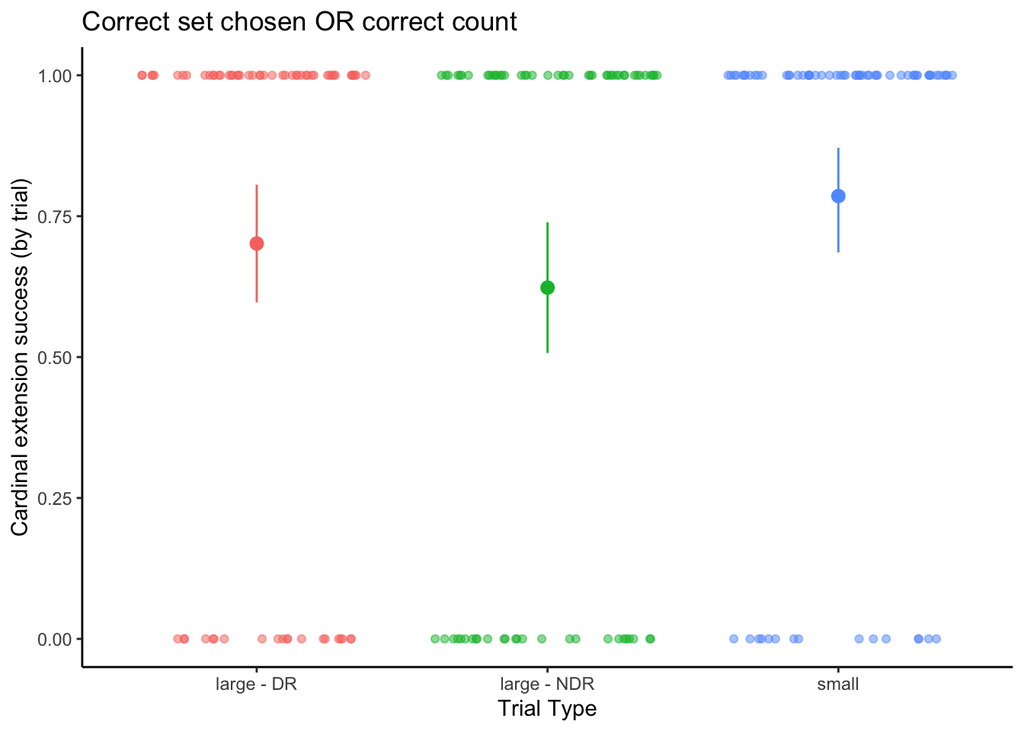

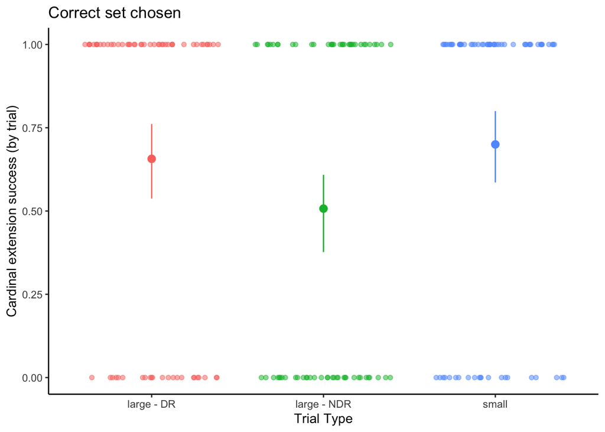

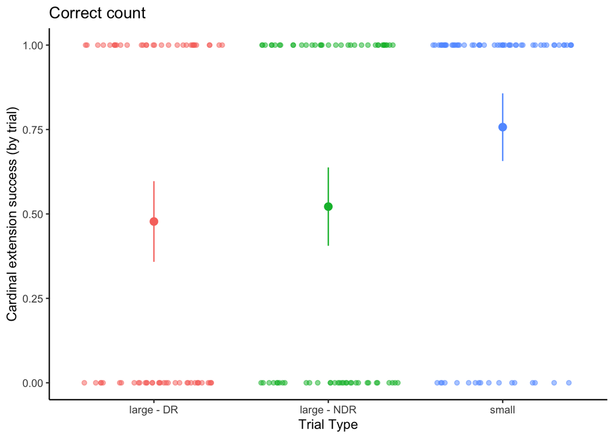

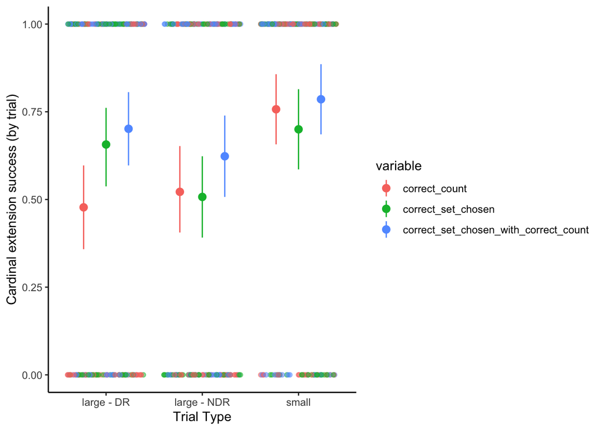

```
## No summary function supplied, defaulting to `mean_se()`
## No summary function supplied, defaulting to `mean_se()`
## No summary function supplied, defaulting to `mean_se()`
```

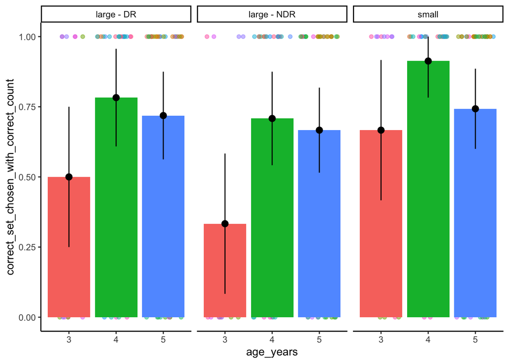

#### By participant

```
## argument.
```

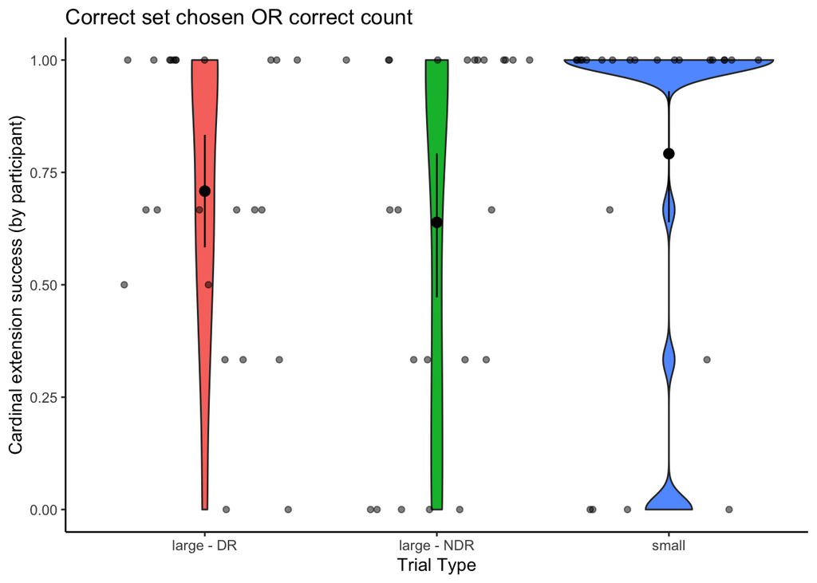

```
## argument.
```

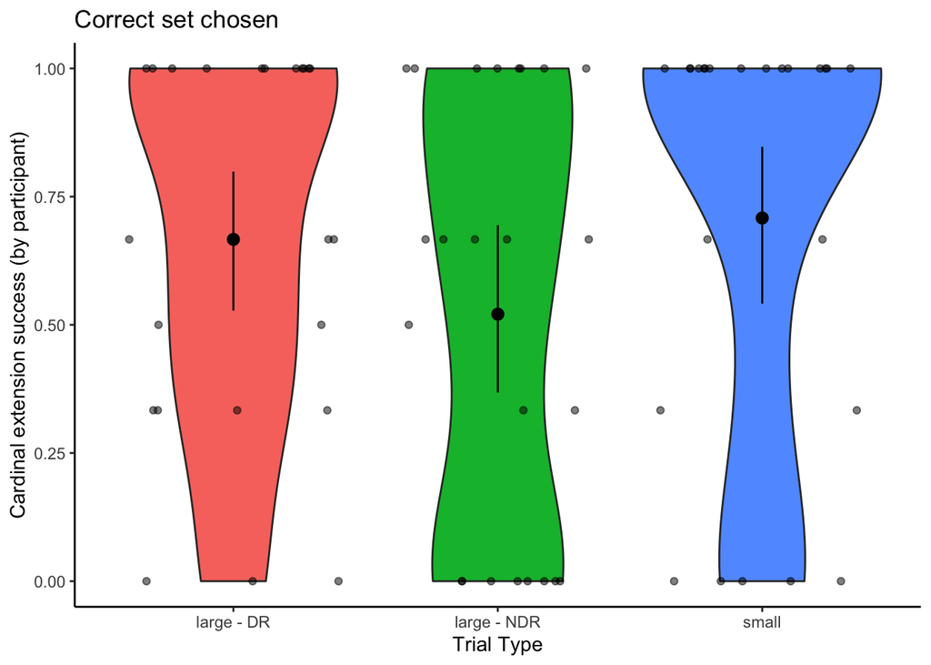

```
## argument.
```

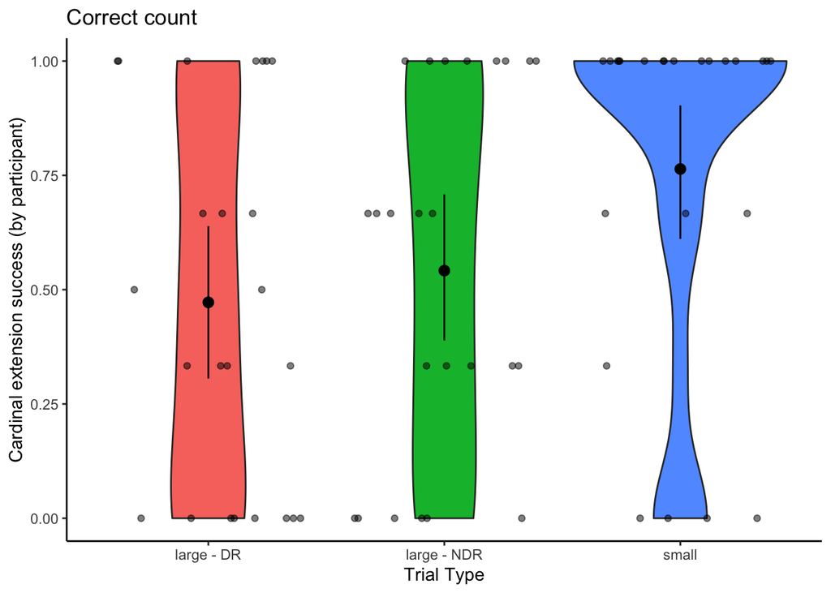

```
## argument.
```

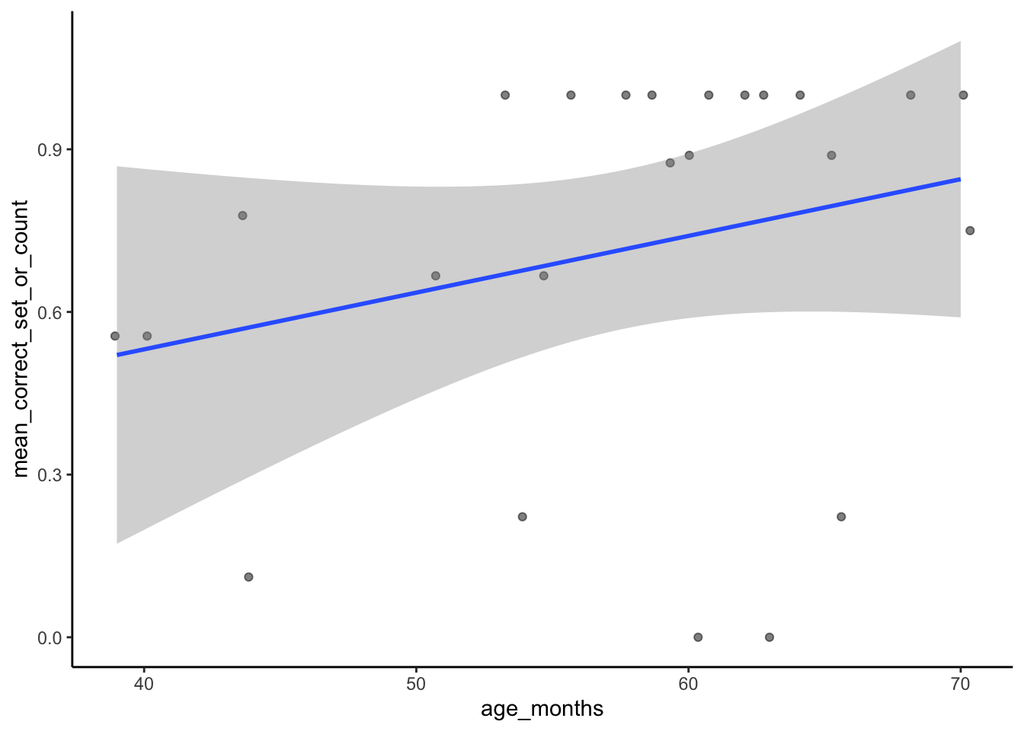

### Approximate correct count

Rose only did this for large set, to take into account kids who might have made a mistake during counting. Still no difference between distinguishable and non-distinguishable ratios. But in any case, they should still have gotten the correct set, since it’s unlikely that they get the correct count for large trials without choosing a set. So maybe this is unnecessary.

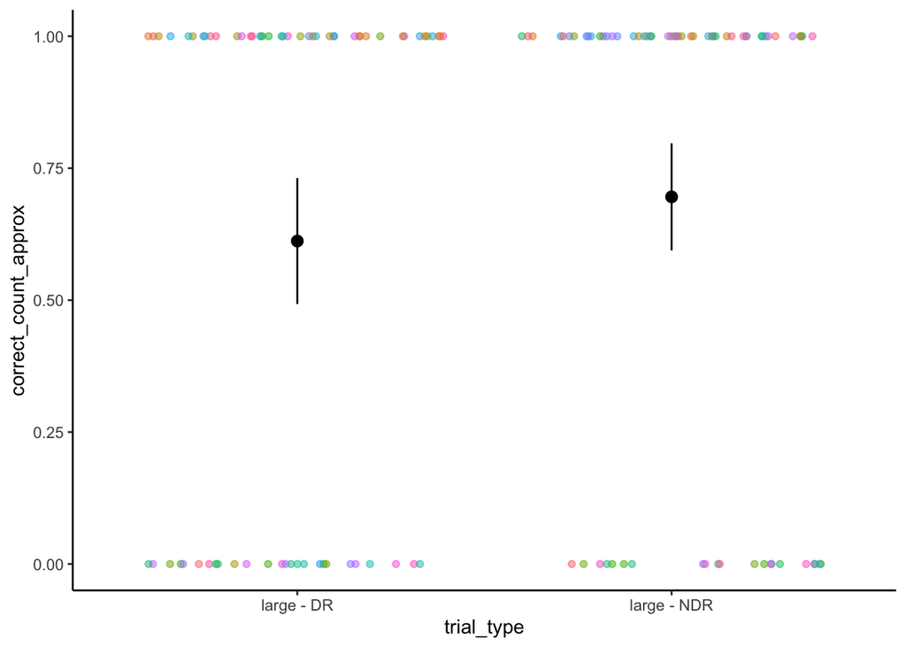

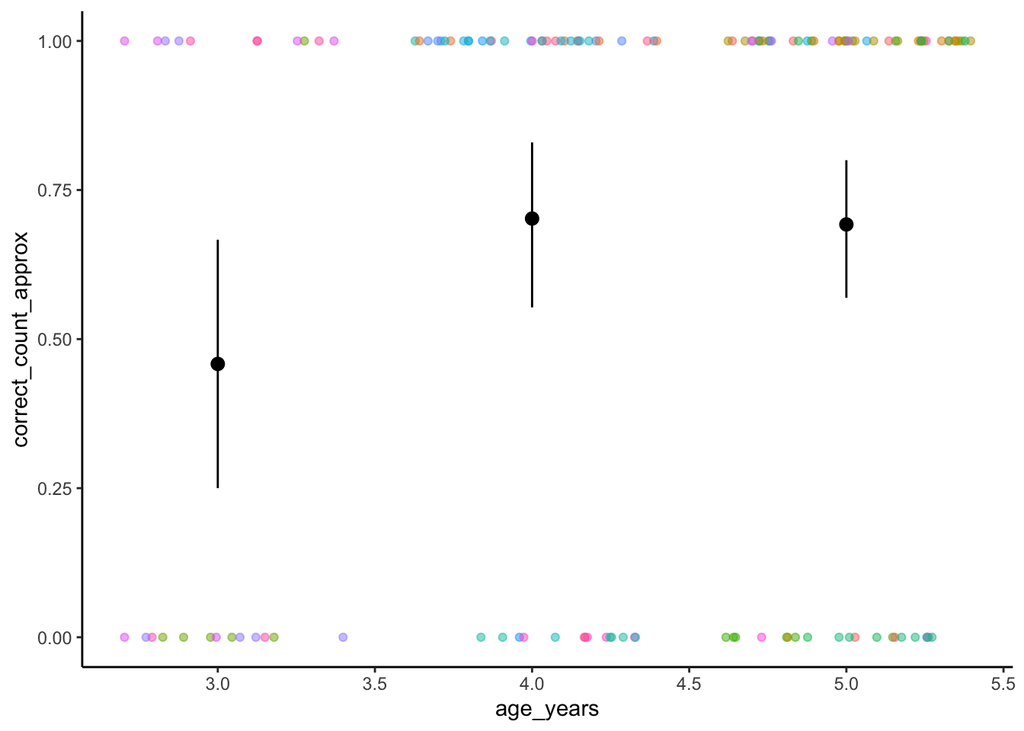

### Error size

Exclude kids who did not finish more than 90% of trials. For only trials where counts are given.

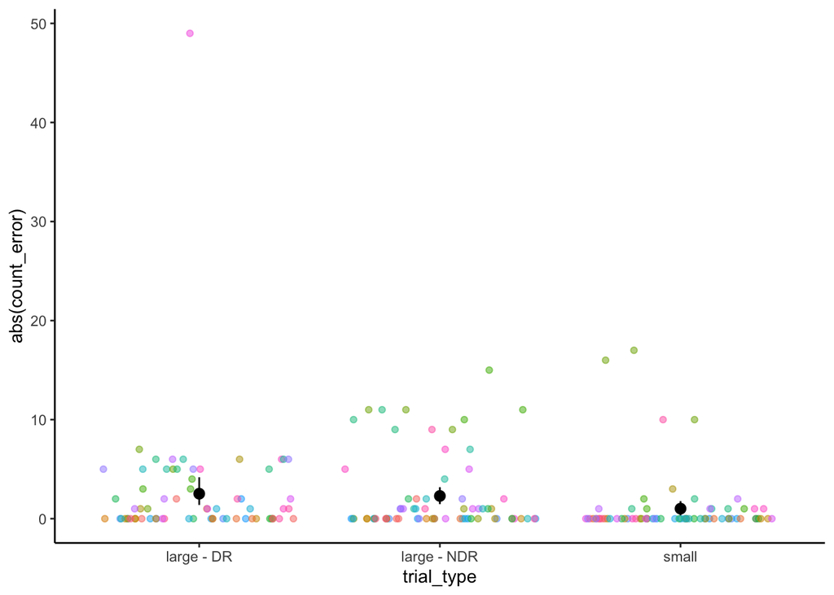

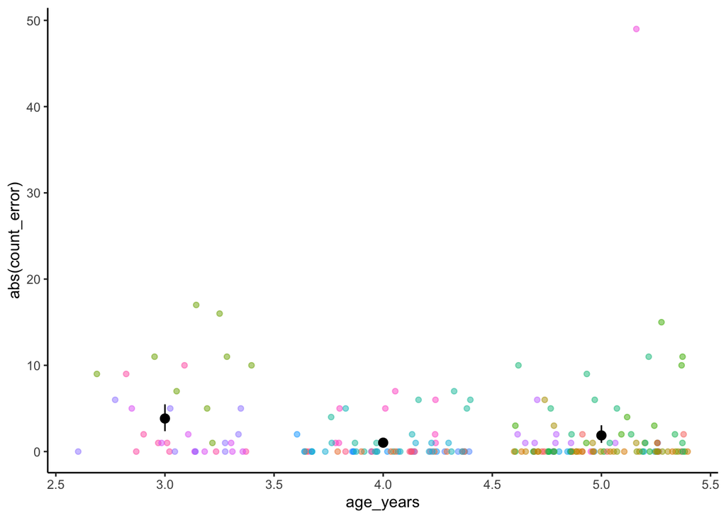

### Regressions

No effect of age. Significant improvement when trial type is added as predictor.

Effect of trial type: significant difference between large - nondistinguishable ratio trials and small trials, but no differences between large distinguishable vs nondistinguishable ratios, or large distinguishable vs small.

When correct set is used as the DV: significant diff between large nondistinguishable ratio vs small, and large distinguishable vs nondistinguishable ratios. But not between large distinguishable vs small.

```
## Generalized linear mixed model fit by maximum likelihood (Laplace
##   Approximation) [glmerMod]
##  Family: binomial  ( logit )
## Formula: correct_set_chosen_with_correct_count ~ age_years + (1 | id) +
##     (1 | trial_ratio)
##    Data: df.trial
##
##      AIC      BIC   logLik deviance df.resid
##    181.0    194.3    -86.5    173.0      202
##
## Scaled residuals:
##     Min      1Q  Median      3Q     Max
## -2.9300 -0.2640  0.1455  0.3494  2.7199
##
## Random effects:
##  Groups      Name        Variance Std.Dev.
##  id          (Intercept) 8.7016   2.9499
##  trial_ratio (Intercept) 0.2095   0.4577
## Number of obs: 206, groups:  id, 24; trial_ratio, 9
##
## Fixed effects:
##             Estimate Std. Error z value Pr(>|z|)
## (Intercept)  -1.9264     3.9265  -0.491    0.624
## age_years     0.9324     0.9217   1.012    0.312
##
## Correlation of Fixed Effects:
##           (Intr)
## age_years -0.979
```

```
## Analysis of Deviance Table (Type III Wald chisquare tests)
##
## Response: correct_set_chosen_with_correct_count
##              Chisq Df Pr(>Chisq)
## (Intercept) 0.2407  1     0.6237
## age_years   1.0233  1     0.3117
```

```
## boundary (singular) fit: see help('isSingular')
```

```
## Generalized linear mixed model fit by maximum likelihood (Laplace
##   Approximation) [glmerMod]
##  Family: binomial  ( logit )
## Formula: correct_set_chosen_with_correct_count ~ trial_type + age_years +
##     (1 | id) + (1 | trial_ratio)
##    Data: df.trial
##
##      AIC      BIC   logLik deviance df.resid
##    176.5    196.5    -82.3    164.5      200
##
## Scaled residuals:
##     Min      1Q  Median      3Q     Max
## -3.1608 -0.2373  0.1341  0.3164  2.6867
##
## Random effects:
##  Groups      Name        Variance Std.Dev.
##  id          (Intercept) 9.555    3.091
##  trial_ratio (Intercept) 0.000    0.000
## Number of obs: 206, groups:  id, 24; trial_ratio, 9
##
## Fixed effects:
##                       Estimate Std. Error z value Pr(>|z|)
## (Intercept)            -2.0232     4.1193  -0.491    0.623
## trial_typelarge - NDR  -0.8164     0.5554  -1.470    0.142
## trial_typesmall         0.8992     0.5982   1.503    0.133
## age_years               0.9714     0.9658   1.006    0.315
##
## Correlation of Fixed Effects:
##             (Intr) t_-NDR trl_ty
## trl_typ-NDR -0.047
## trl_typsmll -0.075  0.447
## age_years   -0.976 -0.037  0.022
## optimizer (Nelder_Mead) convergence code: 0 (OK)
## boundary (singular) fit: see help('isSingular')
```

```
## Analysis of Deviance Table (Type III Wald chisquare tests)
##
## Response: correct_set_chosen_with_correct_count
##              Chisq Df Pr(>Chisq)
## (Intercept) 0.2412  1    0.62332
## trial_type  7.9989  2    0.01833 *
## age_years   1.0116  1    0.31452
## ---
## Signif. codes:  0 '***' 0.001 '**' 0.01 '*' 0.05 '.' 0.1 ' ' 1
```

```
## Data: df.trial
## Models:
## fit.base: correct_set_chosen_with_correct_count ~ age_years + (1 | id) + (1 | trial_ratio)
## fit.trial_type: correct_set_chosen_with_correct_count ~ trial_type + age_years + (1 | id) + (1 | trial_ratio)
##                npar    AIC    BIC  logLik deviance  Chisq Df Pr(>Chisq)
## fit.base          4 180.97 194.28 -86.484   172.97
## fit.trial_type    6 176.52 196.49 -82.259   164.52 8.4499  2    0.01463 *
## ---
## Signif. codes:  0 '***' 0.001 '**' 0.01 '*' 0.05 '.' 0.1 ' ' 1
```

```
## $emmeans
##  trial_type  emmean    SE  df asymp.LCL asymp.UCL
##  large - DR    2.16 0.902 Inf     0.397      3.93
##  large - NDR   1.35 0.858 Inf    -0.334      3.03
##  small         3.06 0.953 Inf     1.195      4.93
##
## Results are given on the logit (not the response) scale.
## Confidence level used: 0.95
##
## $contrasts
##  contrast                     estimate    SE  df z.ratio p.value
##  (large - DR) - (large - NDR)    0.816 0.555 Inf   1.470  0.1415
##  (large - DR) - small           -0.899 0.598 Inf  -1.503  0.1328
##  (large - NDR) - small          -1.716 0.607 Inf  -2.824  0.0047
##
## Results are given on the log odds ratio (not the response) scale.
```

```
## Generalized linear mixed model fit by maximum likelihood (Laplace
##   Approximation) [glmerMod]
##  Family: binomial  ( logit )
## Formula: correct_set_chosen ~ age_years + (1 | id) + (1 | trial_ratio)
##    Data: df.trial
##
##      AIC      BIC   logLik deviance df.resid
##    198.9    212.2    -95.4    190.9      202
##
## Scaled residuals:
##     Min      1Q  Median      3Q     Max
## -3.7532 -0.3565  0.1417  0.3816  3.3704
##
## Random effects:
##  Groups      Name        Variance Std.Dev.
##  id          (Intercept) 7.5319   2.7444
##  trial_ratio (Intercept) 0.8123   0.9013
## Number of obs: 206, groups:  id, 24; trial_ratio, 9
##
## Fixed effects:
##             Estimate Std. Error z value Pr(>|z|)
## (Intercept)  -2.4866     3.6104  -0.689    0.491
## age_years     0.8571     0.8259   1.038    0.299
##
## Correlation of Fixed Effects:
##           (Intr)
## age_years -0.980
```

```
## Analysis of Deviance Table (Type III Wald chisquare tests)
##
## Response: correct_set_chosen
##              Chisq Df Pr(>Chisq)
## (Intercept) 0.4743  1     0.4910
## age_years   1.0770  1     0.2994
```

```
## Generalized linear mixed model fit by maximum likelihood (Laplace
##   Approximation) [glmerMod]
##  Family: binomial  ( logit )
## Formula: correct_set_chosen ~ trial_type + age_years + (1 | id) + (1 |
##     trial_ratio)
##    Data: df.trial
##
##      AIC      BIC   logLik deviance df.resid
##    196.8    216.8    -92.4    184.8      200
##
## Scaled residuals:
##     Min      1Q  Median      3Q     Max
## -3.8413 -0.3464  0.1361  0.3554  2.7122
##
## Random effects:
##  Groups      Name        Variance Std.Dev.
##  id          (Intercept) 7.4307   2.7259
##  trial_ratio (Intercept) 0.1889   0.4347
## Number of obs: 206, groups:  id, 24; trial_ratio, 9
##
## Fixed effects:
##                       Estimate Std. Error z value Pr(>|z|)
## (Intercept)            -2.1562     3.5920  -0.600   0.5483
## trial_typelarge - NDR  -1.3884     0.6626  -2.095   0.0361 *
## trial_typesmall         0.3851     0.6497   0.593   0.5533
## age_years               0.8567     0.8205   1.044   0.2964
## ---
## Signif. codes:  0 '***' 0.001 '**' 0.01 '*' 0.05 '.' 0.1 ' ' 1
##
## Correlation of Fixed Effects:
##             (Intr) t_-NDR trl_ty
## trl_typ-NDR -0.066
## trl_typsmll -0.091  0.472
## age_years   -0.976 -0.041  0.005
```

```
## Analysis of Deviance Table (Type III Wald chisquare tests)
##
## Response: correct_set_chosen
##              Chisq Df Pr(>Chisq)
## (Intercept) 0.3603  1    0.54833
## trial_type  7.6050  2    0.02231 *
## age_years   1.0902  1    0.29643
## ---
## Signif. codes:  0 '***' 0.001 '**' 0.01 '*' 0.05 '.' 0.1 ' ' 1
```

```
## $emmeans
##  trial_type  emmean    SE  df asymp.LCL asymp.UCL
##  large - DR   1.537 0.782 Inf   0.00401      3.07
##  large - NDR  0.148 0.740 Inf  -1.30288      1.60
##  small        1.922 0.793 Inf   0.36812      3.48
##
## Results are given on the logit (not the response) scale.
## Confidence level used: 0.95
##
## $contrasts
##  contrast                     estimate    SE  df z.ratio p.value
##  (large - DR) - (large - NDR)    1.388 0.663 Inf   2.095  0.0361
##  (large - DR) - small           -0.385 0.650 Inf  -0.593  0.5533
##  (large - NDR) - small          -1.774 0.675 Inf  -2.629  0.0086
##
## Results are given on the log odds ratio (not the response) scale.
```

#### Highest count

No effect of highest count

```
## Generalized linear mixed model fit by maximum likelihood (Laplace
##   Approximation) [glmerMod]
##  Family: binomial  ( logit )
## Formula: correct_set_chosen_with_correct_count ~ highest_count + age_years +
##     (1 | id) + (1 | trial_ratio)
##    Data: df.trial %>% filter(!is.na(highest_count))
##
##      AIC      BIC   logLik deviance df.resid
##    181.3    198.0    -85.7    171.3      201
##
## Scaled residuals:
##     Min      1Q  Median      3Q     Max
## -2.8438 -0.2540  0.1598  0.3377  2.5943
##
## Random effects:
##  Groups      Name        Variance Std.Dev.
##  id          (Intercept) 7.6426   2.765
##  trial_ratio (Intercept) 0.2025   0.450
## Number of obs: 206, groups:  id, 24; trial_ratio, 9
##
## Fixed effects:
##               Estimate Std. Error z value Pr(>|z|)
## (Intercept)   -1.19125    3.71875  -0.320    0.749
## highest_count  0.03545    0.02736   1.296    0.195
## age_years      0.47660    0.91561   0.521    0.603
##
## Correlation of Fixed Effects:
##             (Intr) hghst_
## highest_cnt  0.124
## age_years   -0.958 -0.329
```

```
## Analysis of Deviance Table (Type III Wald chisquare tests)
##
## Response: correct_set_chosen_with_correct_count
##                Chisq Df Pr(>Chisq)
## (Intercept)   0.1026  1     0.7487
## highest_count 1.6784  1     0.1951
## age_years     0.2710  1     0.6027
```

```
## boundary (singular) fit: see help('isSingular')
```

```
## Generalized linear mixed model fit by maximum likelihood (Laplace
##   Approximation) [glmerMod]
##  Family: binomial  ( logit )
## Formula: correct_set_chosen_with_correct_count ~ highest_count + trial_type +
##     age_years + (1 | id) + (1 | trial_ratio)
##    Data: df.trial %>% filter(!is.na(highest_count))
##
##      AIC      BIC   logLik deviance df.resid
##    176.9    200.2    -81.4    162.9      199
##
## Scaled residuals:
##     Min      1Q  Median      3Q     Max
## -3.0661 -0.2278  0.1322  0.2890  2.5743
##
## Random effects:
##  Groups      Name        Variance  Std.Dev.
##  id          (Intercept) 8.419e+00 2.902e+00
##  trial_ratio (Intercept) 4.987e-09 7.062e-05
## Number of obs: 206, groups:  id, 24; trial_ratio, 9
##
## Fixed effects:
##                       Estimate Std. Error z value Pr(>|z|)
## (Intercept)           -1.24781    3.90420  -0.320    0.749
## highest_count          0.03725    0.02859   1.303    0.193
## trial_typelarge - NDR -0.81462    0.55536  -1.467    0.142
## trial_typesmall        0.89994    0.59924   1.502    0.133
## age_years              0.49195    0.95972   0.513    0.608
##
## Correlation of Fixed Effects:
##             (Intr) hghst_ t_-NDR trl_ty
## highest_cnt  0.125
## trl_typ-NDR -0.055 -0.033
## trl_typsmll -0.072  0.037  0.447
## age_years   -0.956 -0.330 -0.024  0.006
## optimizer (Nelder_Mead) convergence code: 0 (OK)
## boundary (singular) fit: see help('isSingular')
```

```
## Analysis of Deviance Table (Type III Wald chisquare tests)
##
## Response: correct_set_chosen_with_correct_count
##                Chisq Df Pr(>Chisq)
## (Intercept)   0.1021  1    0.74927
## highest_count 1.6972  1    0.19266
## trial_type    7.9659  2    0.01863 *
## age_years     0.2628  1    0.60823
## ---
## Signif. codes:  0 '***' 0.001 '**' 0.01 '*' 0.05 '.' 0.1 ' ' 1
```